# Mid-gestation fetal cortex dataset: QC and Filtering

**Single cell transcriptomics dataset from paper published by Polioudakis et al. (Geschwind lab, Neuron 2019) characterizing human fetal cortex at mid-gestation**.

[figure not shown]

> Mehtodological approach: Fetal cortical speciments at mid-gestation (gestation week (GW) 17 to 18): germinal zones, developing cortical laminae containing migrating and newly born neurons. To optimize detection of distinct cell types, **prior to single-cell isolation** cortex was separated into:
> - the germinal zones [ventricular zone (VZ) and subventricular zone (SVZ)
> - developing cortex [subplate (SP) and cortical plate (CP)]
- Sequencing method: **Drop-seq** (Macosko et al., 2015)
- Obtained number of cells: **~40,000**

# 1. Environment

## 1.1 Libraries

```python
import numpy as np
import pandas as pd
import igraph as ig
import scanpy as sc
import scanpy.external as sce
from scipy.sparse import csr_matrix, isspmatrix

#Plotting
import matplotlib.pyplot as plt
import seaborn as sns

#ultils
from datetime import datetime
```

```python
sc.logging.print_header()
```

[output not shown]

```
scanpy==1.9.1 anndata==0.8.0 umap==0.5.3 numpy==1.23.5 scipy==1.9.3 pandas==1.5.1 scikit-learn==1.1.3 statsmodels==0.13.5 python-igraph==0.10.2 pynndescent==0.5.8
```

## 1.2 Settings

- Scanpy verbosity
- Figure size
- Result file: the file that will store the analysis results

```python
sc.settings.verbosity = 3
sc.settings.set_figure_params(dpi=80)
```

## 1.3 Custom Plotting Functions

```python
def densityQCs(adataObj, hue=None):
    #Plot them in line so they take up less space
    fig, ax = plt.subplots(1, 4, figsize=(20,5))
    fig.tight_layout(pad=2)   #space between plots

    if hue != None:
        hue_s = adata.obs[hue].astype('string')
    else:
        hue_s = None

    ### Genes ---------------
    d1 = sns.kdeplot(np.log10(adataObj.obs['n_genes_by_counts']), fill=True, color='cornflowerblue', hue=hue_s, ax=ax[0])
    min_x, max_x = d1.get_xlim()

    #Threshold lines and fill
    if MIN_GENES != None:
        d1.axvline(np.log10(MIN_GENES), 0, 1, c='red')  #set manually for chosen threshold
        d1.axvspan(min_x, np.log10(MIN_GENES), alpha=0.2, color='red')
    if MAX_GENES != None:
        d1.axvline(np.log10(MAX_GENES), c='red')
        d1.axvspan(np.log10(MAX_GENES), max_x, alpha=0.2, color='red')

    ### UMI ---------------
    d2 = sns.kdeplot(np.log10(adataObj.obs['total_counts']), fill=True, color='forestgreen', hue=hue_s, ax=ax[1])
    min_x, max_x = d2.get_xlim()

    if MIN_COUNTS != None:
        d2.axvline(np.log10(MIN_COUNTS), 0, 1, c='red')  #set manually for chosen threshold
        d2.axvspan(min_x, np.log10(MIN_COUNTS), alpha=0.2, color='red')
    if MAX_COUNTS != None:
        d2.axvline(np.log10(MAX_COUNTS), c='red')
        d2.axvspan(np.log10(MAX_COUNTS), max_x, alpha=0.2, color='red')

    ### Mito % ---------------
    d3 = sns.kdeplot(adataObj.obs['pct_counts_mito'], fill=True, color='coral', hue=hue_s, ax=ax[2])
    min_x, max_x = d3.get_xlim()

    #Threshold lines and fill
    if MT_PERCENTAGE != None:
        d3.axvline(MT_PERCENTAGE, 0, 1, c='red')  #set manually for chosen threshold
        d3.axvspan(MT_PERCENTAGE, max_x, alpha=0.2, color='red')


    ### Ribo % ---------------
    d4 = sns.kdeplot(adataObj.obs['pct_counts_ribo'], fill=True, color='orchid', hue=hue_s, ax=ax[3])
    min_x, max_x = d4.get_xlim()
    #ax[3].legend(loc='center left', bbox_to_anchor=(1.0, 1.0)) #upper right

    #Threshold lines and fill
    if MT_PERCENTAGE != None:
        d4.axvline(RB_PERCENTAGE, 0, 1, c='red')  #set manually for chosen threshold
        d4.axvspan(RB_PERCENTAGE, max_x, alpha=0.2, color='red')

    #Remove additional legends at need
    if hue != None:
        ax[0].get_legend().remove()
        ax[1].get_legend().remove()
        ax[2].get_legend().remove()

    # Remove all borders
    sns.despine(bottom = False, left = True)
```

## 1.4 Results File

```python
#results_file = '/home/..../brainomics/Data/1_AdataFilt.h5ad'
results_file = '/group/brainomics/Intermediate/1_AdataFilt.h5ad'
```

# 2. Data Load

> Data are already structured as ann AnnData Object. Anndata stores:
> 1. a data matrix **(adata.X)**
> 2. dataframe-like annotation of observations **(adata.obs)** and variables **(adata.var)**
> 3. unstructured dict-like annotation **(adata.uns)**.

[figure not shown]

## 2.1 Read adata file

```python
adata = sc.read('/group/brainomics/course_material/Day2/data/0_AdataStart.h5ad')
```

## 2.2 Explore Adata

```python
adata
```

```
AnnData object with n_obs × n_vars = 33976 × 35543
    obs: 'Cluster', 'Subcluster', 'Donor', 'Layer', 'Gestation_week', 'Index', 'Library', 'Number_genes_detected', 'Number_UMI', 'Percentage_mitochondrial', 'S_phase_score', 'G2M_phase_score', 'Phase'
```

### A. **Count Matrix**

Stores the matrix of values: expression value of each gene in each cell.

```python
adata.X
```

```
<33976x35543 sparse matrix of type '<class 'numpy.float32'>'
	with 35632658 stored elements in Compressed Sparse Row format>
```

```python
print(adata[:10, :2].X)
```

```
  (6, 1)	1.0
  (8, 1)	1.0
```

```python
adata.X.toarray()[:10, :10] #so see it more matrix like
```

```
array([[0., 0., 0., 0., 0., 0., 0., 0., 0., 0.],
       [0., 0., 0., 0., 0., 0., 0., 0., 0., 0.],
       [0., 0., 0., 0., 0., 0., 0., 0., 0., 0.],
       [0., 0., 0., 0., 0., 0., 0., 0., 1., 0.],
       [0., 0., 0., 0., 0., 0., 0., 0., 0., 0.],
       [0., 0., 0., 0., 0., 0., 1., 1., 0., 0.],
       [0., 1., 0., 0., 0., 0., 0., 0., 0., 0.],
       [0., 0., 0., 0., 0., 0., 0., 0., 0., 0.],
       [0., 1., 0., 0., 0., 0., 1., 0., 1., 0.],
       [0., 0., 0., 0., 0., 0., 0., 0., 0., 0.]], dtype=float32)
```

```python
# To store the values in a new object
ACTB_counts = adata[:,['ACTB']].X
ACTB_counts
```

```
<33976x1 sparse matrix of type '<class 'numpy.float32'>'
	with 25604 stored elements in Compressed Sparse Row format>
```

```python
print(ACTB_counts[:10,])
```

```
  (0, 0)	2.0
  (1, 0)	10.0
  (2, 0)	2.0
  (3, 0)	9.0
  (4, 0)	9.0
  (5, 0)	2.0
  (6, 0)	6.0
  (7, 0)	3.0
  (8, 0)	6.0
  (9, 0)	3.0
```

### B. **Cell metadata**

Adata.obs stores the metadata about the observations: cells (rows of the expression matrix).

**Check number and names of cells**

```python
print('Initial number of cells:', adata.n_obs)
```

```
Initial number of cells: 33976
```

```python
print('Cell names: ', adata.obs_names[:10].tolist())
```

```
Cell names:  ['CGCCGTACGTTC', 'TCAGCGTGGACA', 'TATGCTTATGTC', 'TCAGCGTGGACT', 'GATTACCTTATA', 'TCAGCGTGGACC', 'GCGAGGCTCGTG', 'TCCGCTTAGACG', 'TGACCAACACCC', 'GTATCCATTCTC']
```

**Check cell metadata**

```python
print('Available metadata for each cell: ', adata.obs.columns)
```

```
Available metadata for each cell:  Index(['Cluster', 'Subcluster', 'Donor', 'Layer', 'Gestation_week', 'Index',
       'Library', 'Number_genes_detected', 'Number_UMI',
       'Percentage_mitochondrial', 'S_phase_score', 'G2M_phase_score',
       'Phase'],
      dtype='object')
```

```python
adata.obs[:5]
```

|  | Cluster | Subcluster | Donor | Layer | Gestation_week | Index | Library | Number_genes_detected | Number_UMI | Percentage_mitochondrial | S_phase_score | G2M_phase_score | Phase |
| --- | --- | --- | --- | --- | --- | --- | --- | --- | --- | --- | --- | --- | --- |
| CGCCGTACGTTC | ExM | ExM_1 | 368.0 | CP | 17.0 | N701 | Plath | 3056.0 | 9036.0 | 3.18 | -0.0075 | -0.12 | G1 |
| TCAGCGTGGACA | End | End_0 | 368.0 | CP | 17.0 | N701 | Plath | 3144.0 | 7280.0 | 3.46 | -0.0900 | -0.18 | G1 |
| TATGCTTATGTC | ExM | ExM_1 | 368.0 | CP | 17.0 | N701 | Plath | 2778.0 | 7908.0 | 3.63 | -0.0290 | -0.22 | G1 |
| TCAGCGTGGACT | End | End_3 | 368.0 | CP | 17.0 | N701 | Plath | 2936.0 | 6687.0 | 3.14 | -0.0850 | -0.21 | G1 |
| GATTACCTTATA | ExM | ExM_1 | 368.0 | CP | 17.0 | N701 | Plath | 2586.0 | 7111.0 | 4.21 | -0.1200 | -0.16 | G1 |

### C. **Gene metadata**

Adata.var stores the metadata about features: genes (columns of the expression matrix).

```python
adata.var[:5]
```

| TSPAN6 |
| --- |
| DPM1 |
| SCYL3 |
| C1orf112 |
| FGR |

**Check number and names of genes**

```python
print('Initial number of genes:', adata.n_vars)
```

```
Initial number of genes: 35543
```

```python
print('Gene names: ', adata.var_names[:10].tolist())
```

```
Gene names:  ['TSPAN6', 'DPM1', 'SCYL3', 'C1orf112', 'FGR', 'CFH', 'FUCA2', 'GCLC', 'NFYA', 'STPG1']
```

**Check gene metadata**

```python
# To see the gene metadata (information available for each gene)
print('Available metadata for each gene: ', adata.var.columns)
```

```
Available metadata for each gene:  Index([], dtype='object')
```

## 2.3 Explore metadata

### A. **Donors**

> Samples processed for Dropseq were obtained from 4 donors:
> - 3 females (2 GW17, 1 GW18);
> - 1 male (GW18)

```python
adata.obs.Donor = adata.obs.Donor.astype('int').astype('category')
```

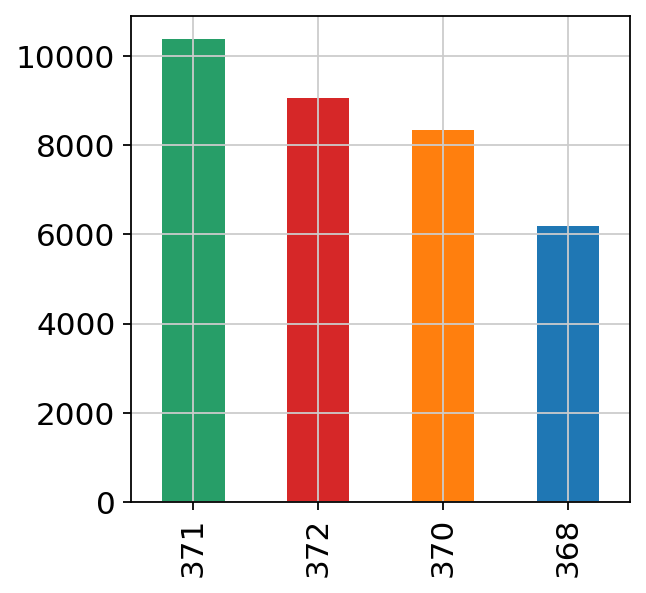

```python
adata.obs['Donor'].value_counts().plot.bar(color=['#279e68', '#d62728', '#ff7f0e', '#1f77b4'])
```

### B. **Gestational Week**

```python
adata.obs['Gestation_week'].value_counts()
```

```
18.0    17396
17.0    16580
Name: Gestation_week, dtype: int64
```

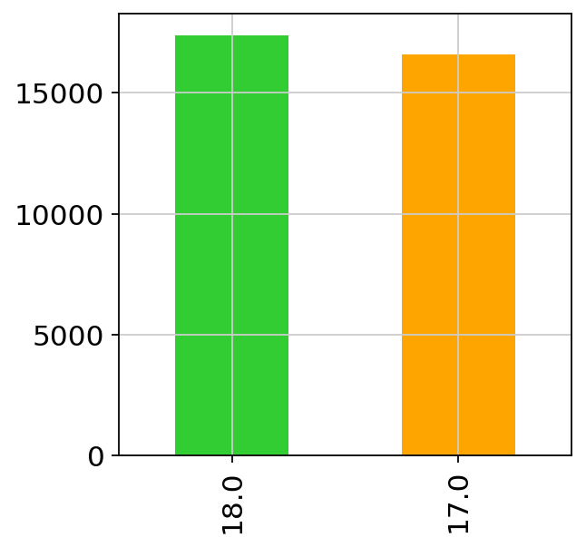

```python
adata.obs['Gestation_week'].value_counts().plot.bar(color=['limegreen', 'orange'])
```

### C. **Layer**

> Coronal sections were prepared from fetal cortices. The coronal sections were then **further dissected** at the intermediate zone (IZ) to divide them into two regions: germinal zones (GZ) and developing cortex (CP). Following dissection, **GZ and CP sections were separately dissociated**.

```python
adata.obs['Layer'].value_counts()
```

```
GZ    17136
CP    16840
Name: Layer, dtype: int64
```

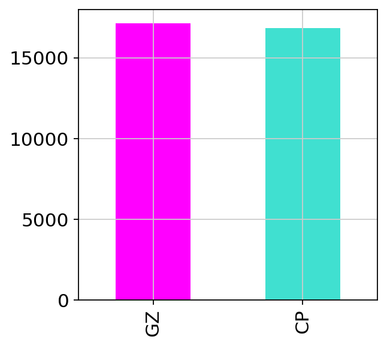

```python
adata.obs['Layer'].value_counts().plot.bar(color=['magenta', 'turquoise'])
```

### D. **Clusters**

```python
adata.obs['Cluster'].value_counts()
```

```
ExN      9995
ExM      9822
IP       2150
ExDp1    2039
ExM-U    1756
InMGE    1705
InCGE    1434
oRG      1293
PgS      1232
vRG       984
PgG2M     695
OPC       306
End       237
ExDp2     166
Per       114
Mic        48
Name: Cluster, dtype: int64
```

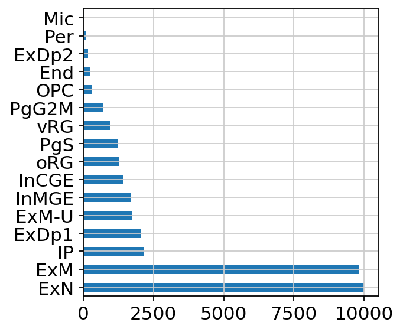

```python
adata.obs['Cluster'].value_counts().plot.barh()
```

**Cell populations identified by the authors:**

- Cycling Progenitor S (PgS)
- Cycling Progenitor G2/M (PgG2M)
- Vetricular Radial Glia (vRG)
- Outer Radial Glia (oRG)
- Intermediate Progenitor (IP)
- Migrating Excitatory (ExN)
- Maturing Excitatory (ExM)
- Maturing Excitatory upper enriched (ExM-U)
- Excitatory Deep Layer 1 (ExDp1)
- Excitatory Deep Layer 2 (ExDp2)
- Interneuron MGE (InMGE)
- Interneuron CGE (InCGE)
- Oligodendrocyte Progenitor (OPC)
- Microglia (Mic)
- Pericytes (Per)
- Endothelia (End)

[figure not shown]

# 3. Top-expressed genes

The plot shows those genes that yield the highest fraction of counts in each single cells, across all cells.

```
normalizing counts per cell
    finished (0:00:00)
```

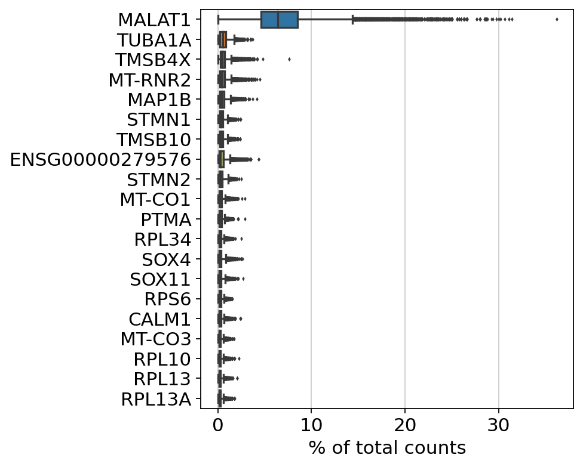

```python
sc.pl.highest_expr_genes(adata, n_top=20)
```

# 4. Quality Check

**Evaluate metrics related to quality as preliminary step for filtering.**

- **Mitochondrial gene counts:** high proportions are indicative of poor-quality cells, related to loss of cytoplasmic RNA from perforated cells: mitochondrial transcripts are protected by mitochondrial membrane and therefore less likely to escape through tears in the cell membrane.
- **Ribosomal Protein gene counts:** high proportion are indicative of a shallow sequencing, because very highly expressed genes occupy most of the reads
- **Number of genes:** related to sequencing depth/quality
- **Number of UMI counts for each gene:** gene-wise sum of UMI counts (in all the cells)

**NOTE:** Thresholds defined below are first showed on diagnostic plots and then applied in the filtering step. You can inspect and change them iteratively until you are satisfied by the results.

### Filtering thresholds

#### **Cell Filtering**

```python
#Cell filtering
MIN_GENES = 500
MAX_GENES = 5000

MIN_COUNTS= 750
MAX_COUNTS= 10000

MT_PERCENTAGE = 5
RB_PERCENTAGE = 20
```

#### **Gene Filtering**

We want to discard genes that are too lowly expressed and thus not informative.

A good approach is to keep genes that are expressed in at least *min_cells*. We identify this minimum number based on the total number of cells in the dataset, selecting around 0.5% of the total fraction of cells

```python
#Gene Filtering
MIN_CELLS = np.rint((adata.n_obs*0.5)/100) # Filtering genes on minimum cells: 0.5%
MIN_CELLS
```

```
170.0
```

**FOOD for THOUGHTS:** to be more stringent on gene filtering, the minimum number of cells may be set **after** filtering low quality cells.

It is convenient especially when starting from a very high number of cells and a lot of them are discarded, as setting the thresholds before filtering may keep some genes even with very few counts in the remaining cells.

### 4.1 Identify Mitocondrial and Ribosomal genes

**The string based selection is not completely accurate** because it can also include genes that are not mitocondrial/ribosomal but share the string used for the selection.

It should be anyway a good enough approximation for our purposes.

**NOTE:** Metadata already contains mito % etc, we recompute them and check if they are coherent.

```python
#Find mito and ribo genes
mito_genes = adata.var_names.str.startswith('MT-')
ribo_genes = adata.var_names.str.contains('^RPS|^RPL')

adata.var_names[mito_genes]
```

```
Index(['MT-ND6', 'MT-CO2', 'MT-CYB', 'MT-ND2', 'MT-ND5', 'MT-CO1', 'MT-ND3',
       'MT-ND4', 'MT-ND1', 'MT-ATP6', 'MT-CO3', 'MT-TL1', 'MT-TF', 'MT-TV',
       'MT-RNR2', 'MT-TI', 'MT-TQ', 'MT-TM', 'MT-TW', 'MT-TA', 'MT-TC',
       'MT-TY', 'MT-TS1', 'MT-TD', 'MT-TG', 'MT-TR', 'MT-TH', 'MT-TS2',
       'MT-TL2', 'MT-TE', 'MT-TT', 'MT-TP', 'MT-RNR1', 'MT-ND4L', 'MT-ATP8'],
      dtype='object')
```

```python
adata.var['mito'] = adata.var_names.str.startswith('MT-')
adata.var['ribo']= adata.var_names.str.contains('^RPS|^RPL')
```

### 4.2 Automated QC metrics

We use the scanpy automated QC metrics function: calculate_qc_metrics in module scanpy.preprocessing._qc. See [calculate_qc_metrics docs](https://scanpy.readthedocs.io/en/stable/api/scanpy.pp.calculate_qc_metrics.html)

```python
sc.pp.calculate_qc_metrics(adata, qc_vars=['mito','ribo'], inplace=True,
                           log1p=False, percent_top=None)
```

```python
adata.obs.head()
```

|  | Cluster | Subcluster | Donor | Layer | Gestation_week | Index | Library | Number_genes_detected | Number_UMI | Percentage_mitochondrial | S_phase_score | G2M_phase_score | Phase | n_genes_by_counts | total_counts | total_counts_mito | pct_counts_mito | total_counts_ribo | pct_counts_ribo |
| --- | --- | --- | --- | --- | --- | --- | --- | --- | --- | --- | --- | --- | --- | --- | --- | --- | --- | --- | --- |
| CGCCGTACGTTC | ExM | ExM_1 | 368 | CP | 17.0 | N701 | Plath | 3056.0 | 9036.0 | 3.18 | -0.0075 | -0.12 | G1 | 3055 | 9035.0 | 287.0 | 3.176536 | 684.0 | 7.570559 |
| TCAGCGTGGACA | End | End_0 | 368 | CP | 17.0 | N701 | Plath | 3144.0 | 7280.0 | 3.46 | -0.0900 | -0.18 | G1 | 3144 | 7280.0 | 252.0 | 3.461539 | 540.0 | 7.417583 |
| TATGCTTATGTC | ExM | ExM_1 | 368 | CP | 17.0 | N701 | Plath | 2778.0 | 7908.0 | 3.63 | -0.0290 | -0.22 | G1 | 2778 | 7908.0 | 287.0 | 3.629236 | 599.0 | 7.574608 |
| TCAGCGTGGACT | End | End_3 | 368 | CP | 17.0 | N701 | Plath | 2936.0 | 6687.0 | 3.14 | -0.0850 | -0.21 | G1 | 2935 | 6686.0 | 210.0 | 3.140891 | 487.0 | 7.283877 |
| GATTACCTTATA | ExM | ExM_1 | 368 | CP | 17.0 | N701 | Plath | 2586.0 | 7111.0 | 4.21 | -0.1200 | -0.16 | G1 | 2585 | 7110.0 | 299.0 | 4.205345 | 464.0 | 6.526020 |

### 4.3 Inspect quality-related parameters

**4.3.1 Mitochondrial genes**

```python
#Print quantiles to get an idea of the value distributions
print(np.quantile(adata.obs['pct_counts_mito'], np.arange(0, 1.1, 0.1)))
```

```
[0.         0.90575981 1.20879126 1.43291944 1.64062488 1.84275186
 2.0667727  2.31792259 2.65060234 3.19561386 5.        ]
```

**4.3.2 Ribosomal Protein genes**

```python
print(np.quantile(adata.obs['pct_counts_ribo'], np.arange(0, 1.1, 0.1)))
```

```
[ 0.          5.61187768  7.030303    8.1046567   8.99500275  9.86598444
 10.81242561 11.87531853 13.13782883 15.02100849 45.82524109]
```

**4.3.3 Total number of counts for each cell**

```python
print(np.quantile(adata.obs['total_counts'], np.arange(0, 1.1, 0.1)))
```

```
[ 216.   551.   786.  1003.  1239.  1503.5 1803.  2181.  2706.  3613.
 9449. ]
```

**4.3.4 Number of genes detected in each cell**

```python
print(np.quantile(adata.obs['n_genes_by_counts'], np.arange(0, 1.1, 0.1)))
```

```
[ 201.   409.   556.   681.   809.   943.  1087.  1257.5 1486.  1839.
 3151. ]
```

### 4.4 Visualization

#### Violin plots: linear values

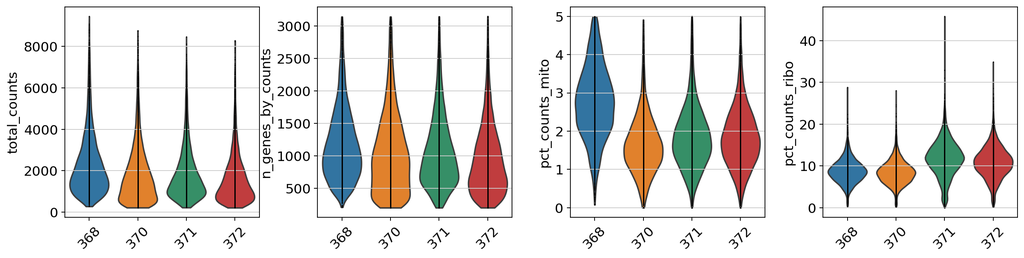

```python
sc.pl.violin(adata, keys=['total_counts', 'n_genes_by_counts', 'pct_counts_mito', 'pct_counts_ribo'],
             jitter=False, multi_panel=True, groupby='Donor', rotation=45)
```

```python
adata.uns['Donor_colors']
```

```
['#1f77b4', '#ff7f0e', '#279e68', '#d62728']
```

#### Violin plots: log values

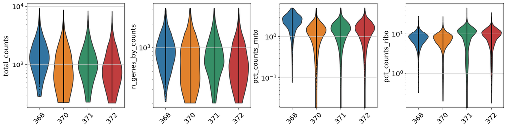

```python
sc.pl.violin(adata, keys=['total_counts', 'n_genes_by_counts', 'pct_counts_mito', 'pct_counts_ribo'],
             jitter=False, multi_panel=True, log=True, groupby='Donor', rotation=45)
```

#### Density plots

##### **Single Plots**

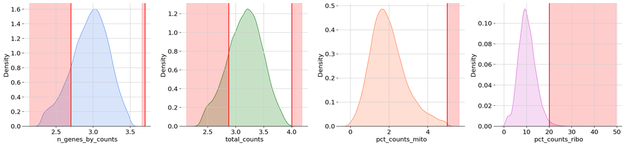

```python
densityQCs(adata)
```

##### **Double Plots**

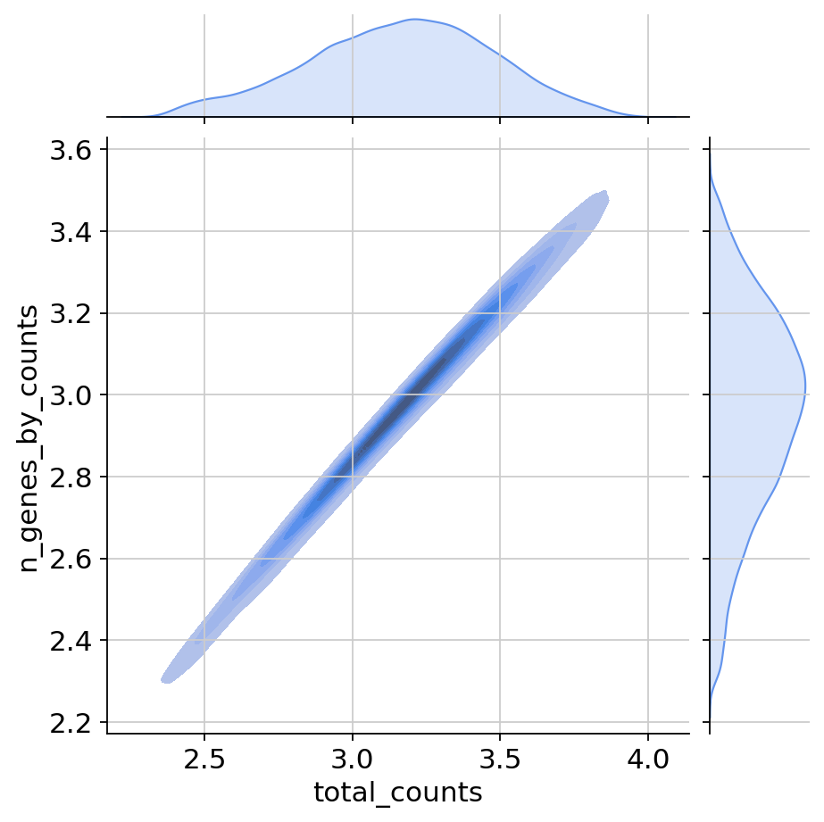

```python
sns.jointplot(x=np.log10(adata.obs['total_counts']),
              y=np.log10(adata.obs['n_genes_by_counts']),
              kind="kde", color="cornflowerblue", fill=True)
```

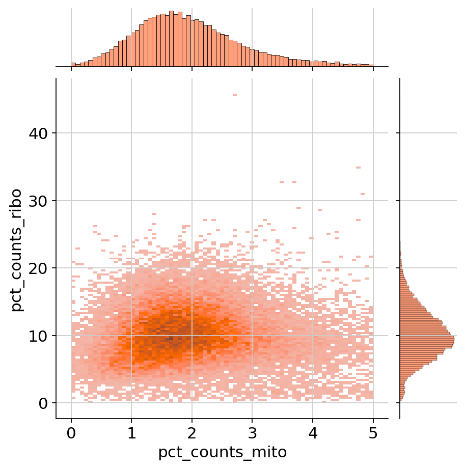

```python
sns.jointplot(x=adata.obs['pct_counts_mito'],
              y=adata.obs['pct_counts_ribo'],
              kind="hist", color="coral")
```

# 5. Filtering

Modify the **threshold variables** cell at the start of the QC to overwrite the default filtering values

```python
print('\nThe selected filtering parameters are: \n Minimum cells: ' , MIN_CELLS,
      '\n Minimum counts: ' , MIN_COUNTS, '\n Maximum counts:' , MAX_COUNTS,
      '\n Minimum genes: ' , MIN_GENES, '\n Maximum genes:' , MAX_GENES,
      '\n Mitocondia: ' , MT_PERCENTAGE, '%', '\n Ribosomal: ', RB_PERCENTAGE, '%')
```

```
The selected filtering parameters are:
 Minimum cells:  170.0
 Minimum counts:  750
 Maximum counts: 10000
 Minimum genes:  500
 Maximum genes: 5000
 Mitocondia:  5 %
 Ribosomal:  20 %
```

## 5.1 Filtering Cells

### 5.1.1 Detected Genes

```python
sc.pp.filter_cells(adata, min_genes=MIN_GENES)
print('After filtering on min detected genes:number of cells:', adata.n_obs)
print()
```

```
filtered out 5401 cells that have less than 500 genes expressed
After filtering on min detected genes:number of cells: 28575
```

### 5.1.2 UMI Counts

```python
sc.pp.filter_cells(adata, min_counts = MIN_COUNTS)
print('After filtering on min UMI counts:number of cells:', adata.n_obs)
```

```
filtered out 893 cells that have less than 750 counts
After filtering on min UMI counts:number of cells: 27682
```

### 5.1.3 Mitochondrial RNA

```python
#adata.obs[adata.obs['percent_mito'] > 0.05]
adata = adata[adata.obs['pct_counts_mito'] < MT_PERCENTAGE, :]

print('After filtering on mitochondrial RNA: number of cells:', adata.n_obs)
```

```
After filtering on mitochondrial RNA: number of cells: 27681
```

### 5.1.4 Ribosomal RNA

```python
#adata = adata[adata.obs['percent_ribo'] < 0.35, :]
adata = adata[adata.obs['pct_counts_ribo'] < RB_PERCENTAGE, :]

print('After filtering on ribosomal protein RNA: number of cells:', adata.n_obs)
```

```
After filtering on ribosomal protein RNA: number of cells: 27457
```

## 5.2 Filtering genes

**Filtered out genes expressed in less than 0.5% of cells**

```python
print('Before gene filtering: number of genes:', adata.n_vars)
print('Before gene filtering: number of cells:', adata.n_obs)
```

```
Before gene filtering: number of genes: 35543
Before gene filtering: number of cells: 27457
```

```python
print(MIN_CELLS) # Filtering genes on minimum cells: 1%
sc.pp.filter_genes(adata, min_cells=MIN_CELLS)
```

```
170.0
filtered out 21598 genes that are detected in less than 170.0 cells
```

```python
print('After gene filtering: number of genes:', adata.n_vars)
print('After filtering: number of cells:', adata.n_obs)
```

```
After gene filtering: number of genes: 13945
After filtering: number of cells: 27457
```

## 5.3 Numbers after filtering

```python
print('After applied filtering: number of cells:', adata.n_obs)
print('After applied filtering: number of genes:', adata.n_vars)
```

```
After applied filtering: number of cells: 27457
After applied filtering: number of genes: 13945
```

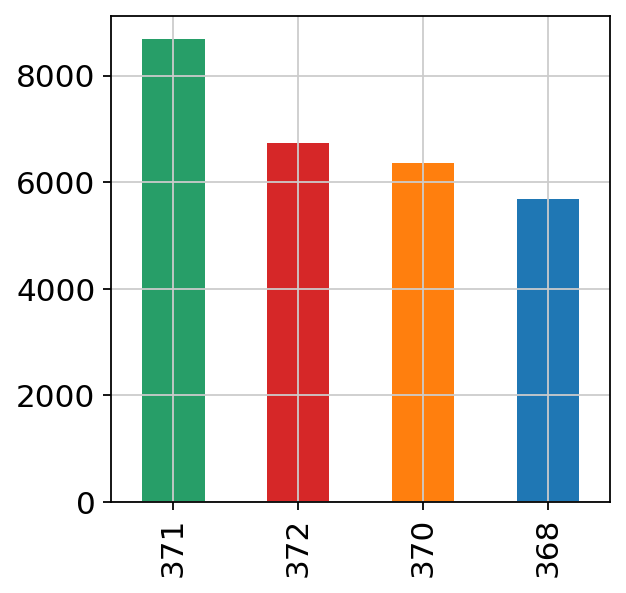

```python
adata.obs['Donor'].value_counts().plot.bar(color=['#279e68', '#d62728', '#ff7f0e', '#1f77b4'])
```

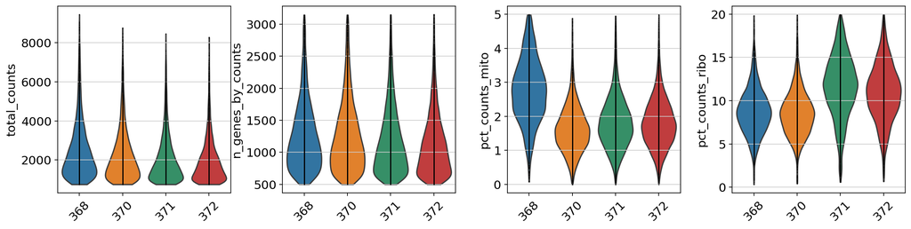

```python
sc.pl.violin(adata, keys=['total_counts', 'n_genes_by_counts', 'pct_counts_mito', 'pct_counts_ribo'], groupby='Donor',
             jitter=False, multi_panel=True, rotation=45)
```

# 6. Save file

## 6.1 Save Adata

```python
type(adata.X)
```

```
scipy.sparse._csr.csr_matrix
```

```python
adata.X
```

```
<27457x13945 sparse matrix of type '<class 'numpy.float32'>'
	with 32277483 stored elements in Compressed Sparse Row format>
```

```python
adata.write(results_file)
```

## 6.2 Finished computations: timestamp

```python
print(datetime.now())
```

```
2022-11-25 19:21:59.298945
```

## 6.3 Save notebook

```python
#nb_fname = ipynbname.name()
nb_fname = '1_QC_Filt'
nb_fname
```

```
'1_QC_Filt'
```

```python
%%bash -s "$nb_fname"
jupyter nbconvert "$1".ipynb --to="python"
jupyter nbconvert "$1".ipynb --to="html"
```

```
[NbConvertApp] Converting notebook 1_QC_Filt.ipynb to python
[NbConvertApp] Writing 16158 bytes to 1_QC_Filt.py
[NbConvertApp] Converting notebook 1_QC_Filt.ipynb to html
[NbConvertApp] Writing 2090166 bytes to 1_QC_Filt.html
```